What is the price of making decisions made based on wrong data or gut feelings? How can one distill trends and predict a behavior from huge ocean of data to help make precise and timely decisions? The answer, very often, is costly and/or critically risky!

# Signal and Noise For Standardized Test Scores

Abiyu Giday

May 11, 2016

> “Any powerful idea is absolutley fascinating  
> and absoluttely usless until  
> we choose to use it.”  
> B. Bach

## Motivation

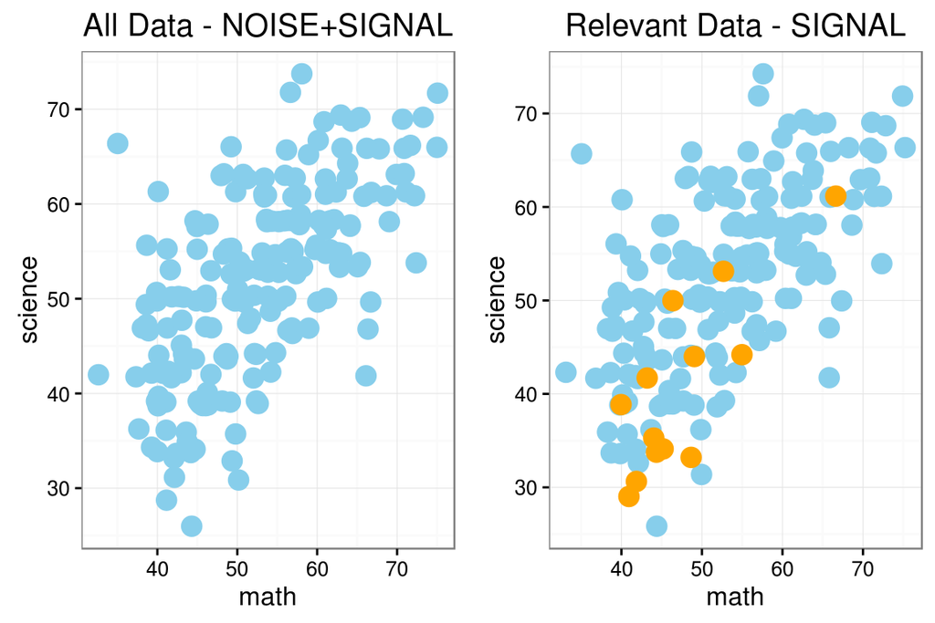

What is the price of making decisions made based on wrong data or gut feelings? How can one distill trends and predict a behavior from huge ocean of data to help make precise and timely decisions? The answer, very often, is costly and/or critically risky! In his book ground braking book **The Signal and the Noise**, the renowned statistician and Data Scientist [Nate Silver](https://en.wikipedia.org/wiki/Nate_Silver), discusses prediction of real word case studies, from cross section of industries, utilizing models based on probability and statistics.

On this paper, I will use statistical programming language R, statistical linear regression model and data visualization dynamic graphs to illuminate how data science can help separate signal (relevant data) from the noise (the rest of the data), to answer a specific question that may be used to craft a policy or assist in making a sound decision.

I will use hypothetical scenario, and data obtained from [UCLA Institute for Digital Research and Education](http://www.ats.ucla.edu/stat/). The data, presumably, is a sample of students test scores for reading, writing, math, science and social studies. Because, school districts often have tens, even hundreds, of thousands of students, statistical random sampling is used, and is proven to be reliable, for accurate reading of the entire the population trend.

## The Question:

> **What is the performance of ‘black’ ‘female’ students who come from lower socio economic households performance in the math and science portion of the test?**

## Tidy data

As always, cleaning the raw data takes lion share of preparing the report. The following snipt of the code labels the raw data factors in to understandable labels. The full data is at the bottom.

```r
df1 <- hsb2 %>%
  # lable race
        mutate(race = as.factor(ifelse(race == 4, "white",
                                ifelse(race == 3, "black",
                                ifelse(race == 2, "asian",
                                ifelse(race == 1, "hispanic",
                                race
                                       ))))
                               )
               )                             %>%
  # lable program type
        mutate(progtyp  = as.factor(ifelse(prog == 3, "vocational",
                                    ifelse(prog == 2, "academic",
                                    ifelse(prog == 1, "general",
                                           prog
                                             )))
                                    )
               )                             %>%
  #  Socio economic status of students
        mutate(socioecon = as.factor(ifelse(ses == 3, "high",
                                     ifelse(ses == 2, "middle",
                                     ifelse(ses == 1, "low",
                                            ses
                                                  )))
                                     )
               )                             %>%
   # Gender
        mutate (gender   = as.factor(ifelse(female   == "1" , "female", "male")))    %>%
   # School type
        mutate (schltype = as.factor(ifelse(schtyp   == "1" , "public", "private")))

   # re-order columns and use the tble data frame
     df2 <- tbl_df(df1[,c(1,12,3,13:15,7:11)])
```

### Average Score Test score by race/gender

The sample data contains for only 200 students, this is likely a random sample of a much larger student population. The following code will summarize and averages the respective grades by race and gender.

|  | race | gender | read | write | math | science | socst |
| --- | --- | --- | --- | --- | --- | --- | --- |
| 1 | asian | female | 52 | 59 | 57 | 51 | 52 |
| 2 | asian | male | 52 | 56 | 59 | 53 | 48 |
| 3 | black | female | 47 | 49 | 48 | 41 | 50 |
| 4 | black | male | 47 | 47 | 45 | 47 | 49 |
| 5 | hispanic | female | 46 | 49 | 45 | 45 | 50 |
| 6 | hispanic | male | 47 | 44 | 49 | 46 | 46 |
| 7 | white | female | 53 | 56 | 54 | 53 | 54 |
| 8 | white | male | 55 | 51 | 54 | 55 | 53 |

## Cross classification

We can add socio economic class, low/mid/high income, to the equation to drill deeper and get a more detailed profile of the students. This is because black female students from high income household who attend private schools tend to perform better and can spike the average test score. Therefore if we separate by race, gender and socio economic background, we can distill a better profile read for this group.

```r
#cross-classifying factors brekdown by race and gender
    with(df2, table(race, gender))
```

```
##           gender
## race       female male
##   asian         8    3
##   black        13    7
##   hispanic     11   13
##   white        77   68
```

```r
    with(df2, table(race, socioecon))
```

```
##           socioecon
## race       high low middle
##   asian       3   3      5
##   black       3  11      6
##   hispanic    4   9     11
##   white      48  24     73
```

## Seprating the Signal from the Noise

The first plot shows the total sample population scatter plot for math and Science. Dplyr filter function is used to grab the black female students. They are identified with the orange color. . This plot doesn’t know which socio economic group the girls belong.

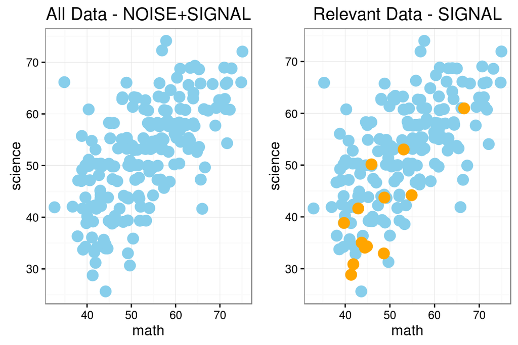

The following graphs split the black female students from the total population for easier contrast. This is where the **signal and noise** effect is shown in graphics.

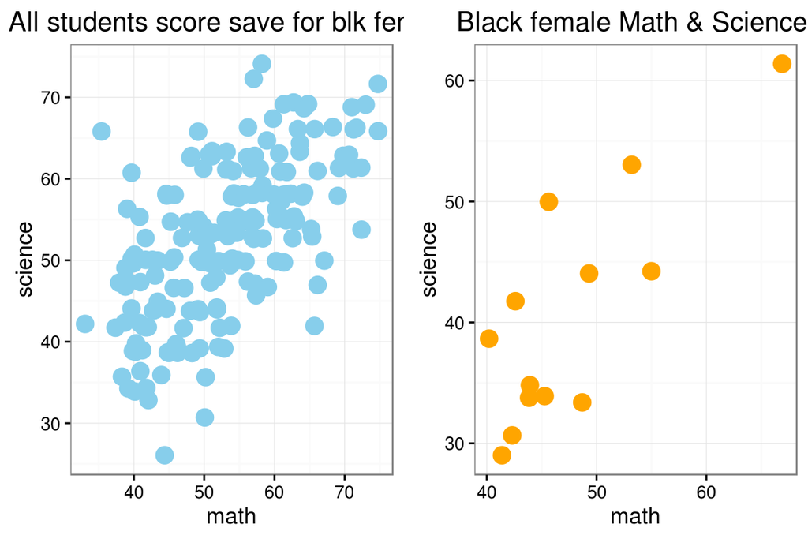

## Visualizting the Data

The following plot answers the question raised at the outset. he graph uses the combinations of ggplot2 and plotly to make it dynamic, in that one can pan zoom and mouse over the points to see how black female students from lower socio economic households fare. By selecting/deselecting the points on the right side one can add/remove other races and socio groups to see the result in isolation.

### plot that answers the question

[interactive chart not shown]

### Linear model plots

The following plot shows the linear regression model for all students and shows with light blue line the direction of the trend for each group. Once again, one can zoom, select/deselect to isolate parts of the data as needed.

[interactive chart not shown]

## Answer to the question:

> ** Black female students from lower socio economic households score lower than all other races and socio economic groups save for black males. There for program focused on this demographic group in math and science is needed to help raise the overall standard.**

For any question or comment drop me an e-amail.

## Code used

This document can be reporduced using the following codes.

```r
# load the libs
library(dplyr)
library(ggplot2)
library(knitr)
library(gridExtra)
library(plotly)

# set working dir
setwd("~/Documents/DataScience/Blogs/Blog6")

# download and save the file in data sub dir
if(!file.exists("./data")){dir.create("./data")}
fileUrl <- "http://www.ats.ucla.edu/stat/data/hsb2_small.csv"
download.file(fileUrl, destfile = "./data/hsb2.csv", method = "curl")

# make csv to tbl data frame
hsb2 <- tbl_df(read.csv("./data/hsb2"))


# tidy the data
df1 <- hsb2 %>%
# lable race
        mutate(race = as.factor(ifelse(race == 4, "white",
                                ifelse(race == 3, "black",
                                ifelse(race == 2, "asian",
                                ifelse(race == 1, "hispanic",
                                race
                                       ))))
                               )
               )                             %>%
# lable program type
        mutate(progtyp  = as.factor(ifelse(prog == 3, "vocational",
                                    ifelse(prog == 2, "academic",
                                    ifelse(prog == 1, "general",
                                           prog
                                             )))
                                    )
               )                             %>%
# Socio economic status of students
        mutate(socioecon = as.factor(ifelse(ses == 3, "high",
                                     ifelse(ses == 2, "middle",
                                     ifelse(ses == 1, "low",
                                            ses
                                                  )))
                                     )
               )                             %>%

# Gender
        mutate (gender   = as.factor(ifelse(female   == "1" , "female", "male")))    %>%

# School type
        mutate (schltype = as.factor(ifelse(schtyp   == "1" , "public", "private")))

# re-order columns and use the tble data frame
     df2 <- tbl_df(df1[,c(1,12,3,13:15,7:11)])


# table list of studetns
# average score for each race and gender for each one of the classes ****
    df4 <- df2 %>% group_by(race, gender) %>%
                          summarise_each(funs(mean),
                          c(read,write,math, science, socst)
                           )
# round result numbers
df4[,-c(1:2)] <- round(df4[,-c(1:2)],0)

# display in table
DT::datatable(df4)

#cross-classifying factors brekdown by race, gender, socio class
    with(df2, table(race, gender))
    with(df2, table(race, socioecon))

#subset blck female
  blk_fml <- subset(df2, race == "black" & gender == "female")


#subset not black female students
  all_other <- df2[!(df2$race == "black" & df2$gender == "female"),]

# plot 1 all data
   p1 <- ggplot(data = df2, aes(x= math, y = science))
      p11 <- p1 + geom_jitter(color = "skyblue", size = 4) +
             #ggtitle("All students Math & Science score") +
             ggtitle("All Data - NOISE+SIGNAL") +
             theme_bw()

#plot 2 - split blk_fml and layer together
   p2 <- ggplot(data = all_other, aes(x= math, y = science))
      p21 <- p2 + geom_jitter(color = "skyblue", size = 4) +
             geom_jitter(data = blk_fml, color = "orange", size = 4) +
             #ggtitle("Black female with all stuedents.") +
             ggtitle("Relevant Data - SIGNAL") +
             theme_bw()

#plot 3 - just blk_fml
   p3 <- ggplot(data = blk_fml, aes(x= math, y = science))
     p31 <-  p3 + geom_jitter(data = blk_fml, color = "orange", size = 4) +
             ggtitle("Black female Math & Science ") +
             theme_bw()

# plot 4 - just all other
    p4 <-    ggplot(data = all_other, aes(x= math, y = science))
      p41 <- p4 + geom_jitter(color = "skyblue", size = 4) +
             ggtitle("All students score save for blk female") +
             theme_bw()

# plot1 – the entire population gray/black
grid.arrange(p11, p21, nrow=1, ncol=2)


#plot2 – signal/noise split population from
grid.arrange(p41, p31, nrow=1, ncol=2)


# plotly fig1 - blk fml low for math and science
 p <- ggplot(data = all_other, aes(x= math, y = science, shape = socioecon)) +
       geom_jitter(data = blk_fml, color = "orange", size = 4)

  ggplotly(
      p + geom_jitter(color = "gray", size = 1) +
      geom_jitter(data = blk_fml, color = "orange", size = 1) +
      geom_abline(intercept = 45, slope = 0, colour = "skyblue", size = 1 ) +
      annotate("text", x = 70, y = 46, label = "most blk fml below 45%", colour = "skyblue", size = 4) +
      ggtitle("Black Female Students Math and Sience standing") +
      xlab("Math score on scale of 0 - 100") +
      ylab("Science score on scale of 0 - 100") +
      theme_minimal() +
      theme(plot.margin = unit(c(1,1,1,1), "cm"))
      )

# plotly fig1 - blk fml low for math and science
ggplotly(
          p + geom_point(shape=3, size = 1) +
          facet_grid(race ~ socioecon) +
          geom_smooth(method="lm", se= FALSE, colour = "skyblue") +
          ggtitle("Over all Math and Sience trends") +
          xlab("Math score on scale of 0 - 100") +
          ylab("Science score on scale of 0 - 100") +
          theme_minimal() +
          theme(plot.margin = unit(c(1,1,1,1), "cm"))
          )
```

END-END-END-END-END-END-END-END-END-END-END-END-END-END-END-END-END-END-END-END-END-END-END